# A Tutorial to Matching

### Compare the Mean after Matching

```r
### Create blank data table
ttest_table_after_match = data.table(varname =character(), t.value=numeric(),
                         p.value = numeric(), mean_no_insurance = numeric(),
                         mean_with_insurance = numeric(), diff = numeric())
### T-test for all variables
for (col in colnames(data_psm[,-c("ProcedureID","weights")])) {
  if (col == "Insurance") next
  zz = t.test(get(col)~get("Insurance"),data = data_psm)
  tvalue = zz$statistic[[1]]
  pvalue = zz$p.value
  mean1 = zz$estimate[[1]]
  mean2 = zz$estimate[[2]]
  temp = ttest_table_after_match[,list(varname = col, t.value = tvalue,
                           p.value = pvalue, mean_no_insurance = mean1,
                           mean_with_insurance = mean2,
                           diff = mean1 - mean2)]
  ttest_table_after_match = rbind(temp,ttest_table_after_match)
}

kable(ttest_table_after_match, caption = "Matching Results")
```

Matching Results

| varname | t.value | p.value | mean_no_insurance | mean_with_insurance | diff |
| --- | --- | --- | --- | --- | --- |
| AvgSales | -2.0265040 | 0.0430901 | 1.783172e+00 | 2.579934e+00 | -0.7967617 |
| GroupPurchase | -0.1047732 | 0.9165798 | 1.164384e-01 | 1.187215e-01 | -0.0022831 |
| Financing | -0.2352723 | 0.8140525 | 7.511416e-01 | 7.579909e-01 | -0.0068493 |
| Ad | -0.4915656 | 0.6231502 | 7.762560e-02 | 8.675800e-02 | -0.0091324 |
| ReviewBonus | 0.0000000 | 1.0000000 | 2.283100e-03 | 2.283100e-03 | 0.0000000 |
| SurgeonNum | 0.4075236 | 0.6837282 | 1.178082e+00 | 1.164384e+00 | 0.0136986 |
| Public | 0.1368299 | 0.8911968 | 6.621000e-02 | 6.392690e-02 | 0.0022831 |
| PriceOrigin | 0.7750393 | 0.4385341 | 1.192253e+04 | 1.095673e+04 | 965.8013699 |
| PricePaid | 0.6450275 | 0.5190841 | 5.821468e+03 | 5.337893e+03 | 483.5753425 |
| PriceDeposit | 0.7031793 | 0.4821321 | 9.472489e+02 | 8.740251e+02 | 73.2237443 |
| AvgReviews | 0.3271905 | 0.7436030 | 4.435464e-01 | 4.253067e-01 | 0.0182397 |
| AvgCompNum | -0.8078392 | 0.4194031 | 2.273981e+00 | 2.426153e+00 | -0.1521723 |
| ProcedureAge | 0.7020793 | 0.4828175 | 7.248858e+00 | 7.011416e+00 | 0.2374429 |

Notice, the p-value of most variables are larger than .05, which means the characteristics of insured and uninsured procedures are now balanced. Now let’s use the new data for multiple regression.

Next, we use the matching data to run the same multiple regression as above.

```r
## Multiple linear regression
mlr_after_psm = lm(AvgSales~Insurance + ProcedureAge + AvgCompNum + AvgReviews + PriceDeposit + PricePaid + PriceOrigin + Public + SurgeonNum + ReviewBonus + Ad + Financing + GroupPurchase, data = data_psm)
## Output the regression results
kable(summary(mlr_after_psm)$coefficients, caption = "Multiple Linear Regression after PSM Matching")
```

Multiple Linear Regression after PSM Matching

|  | Estimate | Std. Error | t value | Pr(>\|t\|) |
| --- | --- | --- | --- | --- |
| (Intercept) | -0.5902746 | 0.8203206 | -0.7195657 | 0.4719875 |
| Insurance | 0.7784712 | 0.3686620 | 2.1116123 | 0.0350070 |
| ProcedureAge | -0.0460492 | 0.0385523 | -1.1944612 | 0.2326262 |
| AvgCompNum | 0.0851262 | 0.0679731 | 1.2523506 | 0.2107818 |
| AvgReviews | 2.1967962 | 0.2280092 | 9.6346830 | 0.0000000 |
| PriceDeposit | -0.0006190 | 0.0002685 | -2.3056423 | 0.0213672 |
| PricePaid | 0.0000556 | 0.0000488 | 1.1388090 | 0.2550992 |
| PriceOrigin | -0.0000174 | 0.0000245 | -0.7101113 | 0.4778272 |
| Public | 0.3115122 | 0.8705378 | 0.3578388 | 0.7205516 |
| SurgeonNum | 0.9808740 | 0.3809577 | 2.5747583 | 0.0101968 |
| ReviewBonus | -0.4248975 | 3.8672886 | -0.1098696 | 0.9125384 |
| Ad | 0.4650894 | 0.6864271 | 0.6775511 | 0.4982382 |
| Financing | 0.8248632 | 0.5000810 | 1.6494591 | 0.0994179 |
| GroupPurchase | 1.5313094 | 0.5868795 | 2.6092398 | 0.0092316 |

The effect of insurance with the matched data shows a significant result under .05 significant level.

## Coarsened Exact Matching

Coarsened exact matching allows us to coarsen each covariate automatically or mannually.

### Automatical Coarsening

Coarsened exact matching allows us to coarsen each covariate automatically or mannually. Without any priori knowledge, we can first try automatical coarsening. Several options are available such as “sturges”. How to choose the appropriate option depends on the distribution of the variables. Notice, there is no sense to coarsen dummy variables (i.e., binary variables) since they are already “coarsened” into two categories. In our case, ProcedureAge, AvgCompNum, AvgReviews, PriceDeposit, PricePaid, and PriceOrigin are continuous variables. We use “sturges” option to coarsen these continuous variables. SurgeonNum is a categorical variable including five categories, we coarsen it into two categories: procedures that one or less physician is available, and procedures that multiple physicians are available. All the other variables are dummies, so we use 0.5 as the cut point to keep them unchanged. You can also use any number strictly between 0 and 1 as the cut point.

The following codes show how we coarsen each variable.

```r
## Automatical coarsening for continuous variables
cut_auto = list(PriceDeposit = "sturges",PricePaid = "sturges", PriceOrigin = "sturges",ProcedureAge = "sturges", AvgCompNum = "sturges", SurgeonNum = c(1.5), AvgReviews = "sturges", Public = c(0.5), ReviewBonus = c(0.5),Ad = c(0.5),Financing = c(0.5),GroupPurchase = c(0.5))
```

We first check imbalance before matching.

```r
## Check the imbalance
rr = imbalance(data$Insurance, data, drop=c("ProcedureID","AvgSales","Insurance"), breaks = cut_auto)
kable(rr$tab, caption = "Imbalance before CEM from Automatical Coarsening")
```

Imbalance before CEM from Automatical Coarsening

|  | statistic | type | L1 | min | 25% | 50% | 75% | max |
| --- | --- | --- | --- | --- | --- | --- | --- | --- |
| ProcedureAge | -0.5592392 | (diff) | 0.0913662 | 0 | 0.00000e+00 | 0.0000000 | 0.000000 | 3 |
| AvgCompNum | -2.7664936 | (diff) | 0.2743672 | 0 | -7.50000e-01 | -1.5000000 | -4.333333 | -9 |
| AvgReviews | -0.0651417 | (diff) | 0.0130867 | 0 | -9.09091e-02 | -0.0735294 | 0.000000 | -5 |
| PriceDeposit | 208.0239381 | (diff) | 0.0980358 | -19 | -5.60000e+01 | -63.0000000 | 438.000000 | 0 |
| PricePaid | 2420.1247097 | (diff) | 0.0835605 | -89 | -3.81000e+02 | -420.0000000 | 3200.000000 | 82000 |
| PriceOrigin | 4306.7888770 | (diff) | 0.1357124 | -581 | -1.70000e+03 | 0.0000000 | 7000.000000 | 18999 |
| Public | -0.0268919 | (diff) | 0.0268919 | 0 | 0.00000e+00 | 0.0000000 | 0.000000 | 0 |
| SurgeonNum | -0.2836647 | (diff) | 0.0000000 | 0 | 0.00000e+00 | 0.0000000 | -1.000000 | -2 |
| ReviewBonus | 0.0013541 | (diff) | 0.0013541 | 0 | 0.00000e+00 | 0.0000000 | 0.000000 | 0 |
| Ad | -0.0697095 | (diff) | 0.0697095 | 0 | 0.00000e+00 | 0.0000000 | 0.000000 | 0 |
| Financing | -0.0961171 | (diff) | 0.0961171 | 0 | -1.00000e+00 | 0.0000000 | 0.000000 | 0 |
| GroupPurchase | -0.0476122 | (diff) | 0.0476122 | 0 | 0.00000e+00 | 0.0000000 | 0.000000 | 0 |

The multivariate imbalance measure $L1$ ranges from 0 to 1, where a value of 1 indicates a complete separation of two distributions and 0 indicates perfect matching. For more details, please refer to [this paper](https://cran.r-project.org/web/packages/cem/vignettes/cem.pdf). We next run CEM with automatical coarsening.

```r
cem_auto <- cem(treatment = "Insurance", data = data, cutpoints = cut_auto, keep.all=TRUE,eval.imbalance = TRUE, drop = c("ProcedureID","AvgSales","Insurance"), L1.breaks = cut_auto )
kable(cem_auto$imbalance$tab, caption = "Imbalance after CEM from Automatical Coarsening")
```

Imbalance after CEM from Automatical Coarsening

|  | statistic | type | L1 | min | 25% | 50% | 75% | max |
| --- | --- | --- | --- | --- | --- | --- | --- | --- |
| ProcedureAge | 0.0156781 | (diff) | 0.0522841 | 0 | 0 | 0.00000e+00 | 0.0 | 0.0000000 |
| AvgCompNum | -0.1253308 | (diff) | 0.0579519 | 0 | 0 | -2.50000e-01 | 0.0 | 1.0000000 |
| AvgReviews | -0.0293110 | (diff) | 0.0683707 | 0 | 0 | -3.33333e-02 | -0.1 | 0.4761905 |
| PriceDeposit | -68.5021152 | (diff) | 0.0740709 | -19 | -55 | -1.12000e+02 | -160.0 | 240.0000000 |
| PricePaid | -302.7151784 | (diff) | 0.0871064 | -89 | -400 | -5.81000e+02 | -720.0 | 1200.0000000 |
| PriceOrigin | -1012.0599975 | (diff) | 0.1741723 | -581 | -1320 | -1.20000e+03 | -800.0 | -888.0000000 |
| Public | 0.0000000 | (diff) | 0.0000000 | 0 | 0 | 0.00000e+00 | 0.0 | 0.0000000 |
| SurgeonNum | -0.2962837 | (diff) | 0.0000000 | 0 | 0 | 0.00000e+00 | -1.0 | -1.0000000 |
| ReviewBonus | 0.0000000 | (diff) | 0.0000000 | 0 | 0 | 0.00000e+00 | 0.0 | 0.0000000 |
| Ad | 0.0000000 | (diff) | 0.0000000 | 0 | 0 | 0.00000e+00 | 0.0 | 0.0000000 |
| Financing | 0.0000000 | (diff) | 0.0000000 | 0 | 0 | 0.00000e+00 | 0.0 | 0.0000000 |
| GroupPurchase | 0.0000000 | (diff) | 0.0000000 | 0 | 0 | 0.00000e+00 | 0.0 | 0.0000000 |

### Manual Coarsening

How to choose the appropriate option for automatical coarsening depends on the distribution of the variables. For example, sturges rule works well for normally distributed variable. Therefore, it is important to check the distributions of all continuous variables before matching. The following histogram shows that most variables are highly right-skewed. Therefore, using “sturges” rule as the approach of automatical coarsening may not be a good choice.

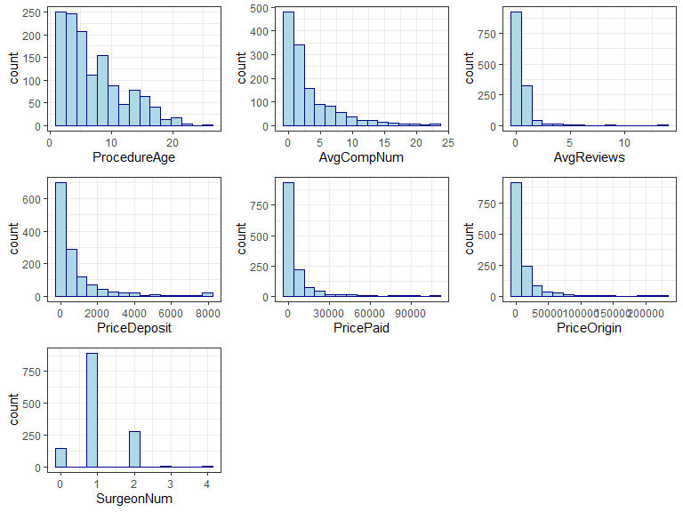

```r
library(ggplot2)
ProcedureAgeHist <- ggplot(data, aes(x=ProcedureAge)) + geom_histogram(bins = 15, color="darkblue", fill="lightblue") + theme_bw() +
  xlab("ProcedureAge")

AvgCompNumHist <- ggplot(data, aes(x=AvgCompNum)) + geom_histogram(bins = 15, color="darkblue", fill="lightblue") + theme_bw() +
  xlab("AvgCompNum")

AvgReviewsHist <- ggplot(data, aes(x=AvgReviews)) + geom_histogram(bins = 15, color="darkblue", fill="lightblue") + theme_bw() +
  xlab("AvgReviews")

PriceDepositHist <- ggplot(data, aes(x=PriceDeposit)) + geom_histogram(bins = 15, color="darkblue", fill="lightblue") + theme_bw() +
  xlab("PriceDeposit")

PricePaidHist <- ggplot(data[PricePaid<150000], aes(x=PricePaid)) + geom_histogram(bins = 15, color="darkblue", fill="lightblue") + theme_bw() +
  xlab("PricePaid")

PriceOriginHist <- ggplot(data, aes(x=PriceOrigin)) + geom_histogram(bins = 15, color="darkblue", fill="lightblue") + theme_bw() +
  xlab("PriceOrigin")

SurgeonNumHist <- ggplot(data, aes(x=SurgeonNum)) + geom_histogram(bins = 15, color="darkblue", fill="lightblue") + theme_bw() +
  xlab("SurgeonNum")

library(gridExtra)
grid.arrange( ProcedureAgeHist, AvgCompNumHist,AvgReviewsHist,PriceDepositHist,PricePaidHist,PriceOriginHist,SurgeonNumHist, ncol=3)
```

In practice, manual coarsening is more reasonable. For example, if the range of price is from $100 to $100,00, we can separate this interval into three pieces with two cut points (e.g., $499.5 and $1999.5):

- $100-$500: low price
- $500-$2000: medium price
- $2000-$100,00: high price

Notice, how to coarsen a variable highly depends on priori knowledge. In this situation, consulting a physician could help a lot. The downside of it is that people may critisize the coarsening is very arbitrary and could be an “artifact” to make the matching result better than real. The following codes show how to define cut points with R and how to use manually defined coarsening for CEM.

```r
## Define cut points
PriceDepositCut = c(99.5,999.5)
PricePaidCut = c(999.5,4999.5,9999.5)
PriceOriginCut = c(999.5,4999.5,9999.5)
ProcedureAgeCut = 2
AvgCompNumCut = 2
SurgeonNumCut = c(0.5,1.5)
AvgReviewsCut = 2

## Save the cut points into a list
cut_man = list(ProcedureAge = ProcedureAgeCut, AvgCompNum = AvgCompNumCut, AvgReviews = AvgReviewsCut, PriceDeposit = PriceDepositCut, PricePaid = PricePaidCut, PriceOrigin = PriceOriginCut,  SurgeonNum = SurgeonNumCut,Public = c(0.5), ReviewBonus = c(0.5),Ad = c(0.5),Financing = c(0.5),GroupPurchase = c(0.5))
```

After defining the cut points, we can run CEM with the manual coarsening. We first check the imbalance of our data.

```r
### Imbalance before matching
rr = imbalance(data$Insurance, data, drop=c("ProcedureID","AvgSales", "Insurance"), breaks = cut_man)
kable(rr$tab, caption = "Imbalance before CEM from Manual Coarsening")
```

Imbalance before CEM from Manual Coarsening

|  | statistic | type | L1 | min | 25% | 50% | 75% | max |
| --- | --- | --- | --- | --- | --- | --- | --- | --- |
| ProcedureAge | -0.5592392 | (diff) | 0.0000000 | 0 | 0.00000e+00 | 0.0000000 | 0.000000 | 3 |
| AvgCompNum | -2.7664936 | (diff) | 0.0000000 | 0 | -7.50000e-01 | -1.5000000 | -4.333333 | -9 |
| AvgReviews | -0.0651417 | (diff) | 0.0000000 | 0 | -9.09091e-02 | -0.0735294 | 0.000000 | -5 |
| PriceDeposit | 208.0239381 | (diff) | 0.0000000 | -19 | -5.60000e+01 | -63.0000000 | 438.000000 | 0 |
| PricePaid | 2420.1247097 | (diff) | 0.0000000 | -89 | -3.81000e+02 | -420.0000000 | 3200.000000 | 82000 |
| PriceOrigin | 4306.7888770 | (diff) | 0.0000000 | -581 | -1.70000e+03 | 0.0000000 | 7000.000000 | 18999 |
| Public | -0.0268919 | (diff) | 0.0268919 | 0 | 0.00000e+00 | 0.0000000 | 0.000000 | 0 |
| SurgeonNum | -0.2836647 | (diff) | 0.0935879 | 0 | 0.00000e+00 | 0.0000000 | -1.000000 | -2 |
| ReviewBonus | 0.0013541 | (diff) | 0.0013541 | 0 | 0.00000e+00 | 0.0000000 | 0.000000 | 0 |
| Ad | -0.0697095 | (diff) | 0.0697095 | 0 | 0.00000e+00 | 0.0000000 | 0.000000 | 0 |
| Financing | -0.0961171 | (diff) | 0.0961171 | 0 | -1.00000e+00 | 0.0000000 | 0.000000 | 0 |
| GroupPurchase | -0.0476122 | (diff) | 0.0476122 | 0 | 0.00000e+00 | 0.0000000 | 0.000000 | 0 |

Next, we run the command for CEM. Notice, the $L1$ statistics decrease a lot after matching.

```r
### CEM matching
cem_man <- cem(treatment = "Insurance", data = data, keep.all=TRUE, eval.imbalance = TRUE, drop = c("ProcedureID","Insurance",  "AvgSales"),cutpoints = cut_man, L1.breaks = cut_man )

## Show imbalance measurement after matching
kable(cem_man$imbalance$tab, caption = "Imbalance after CEM from Manual Coarsening")
```

Imbalance after CEM from Manual Coarsening

|  | statistic | type | L1 | min | 25% | 50% | 75% | max |
| --- | --- | --- | --- | --- | --- | --- | --- | --- |
| ProcedureAge | -0.7652942 | (diff) | 0 | 0 | 0.00000e+00 | 0.00 | -1 | 3 |
| AvgCompNum | -2.4336200 | (diff) | 0 | 0 | -7.50000e-01 | -1.50 | -4 | -9 |
| AvgReviews | -0.0616873 | (diff) | 0 | 0 | -8.33333e-02 | -0.05 | 0 | -5 |
| PriceDeposit | -92.8104916 | (diff) | 0 | -19 | -4.00000e+01 | -56.00 | -40 | 0 |
| PricePaid | -664.3087713 | (diff) | 0 | -89 | -1.82000e+02 | -98.00 | -200 | 82000 |
| PriceOrigin | -1102.5720024 | (diff) | 0 | -581 | -1.00000e+03 | -300.00 | -820 | 18999 |
| Public | 0.0000000 | (diff) | 0 | 0 | 0.00000e+00 | 0.00 | 0 | 0 |
| SurgeonNum | -0.2413341 | (diff) | 0 | 0 | 0.00000e+00 | 0.00 | 0 | -1 |
| ReviewBonus | 0.0000000 | (diff) | 0 | 0 | 0.00000e+00 | 0.00 | 0 | 0 |
| Ad | 0.0000000 | (diff) | 0 | 0 | 0.00000e+00 | 0.00 | 0 | 0 |
| Financing | 0.0000000 | (diff) | 0 | 0 | 0.00000e+00 | 0.00 | 0 | 0 |
| GroupPurchase | 0.0000000 | (diff) | 0 | 0 | 0.00000e+00 | 0.00 | 0 | 0 |

### Use the results of CEM

Here, we take the manual coarsening as example to show how to use the results of CEM. First, as what we did for PSM, we select the weight and combine it with the original data.

```r
data_cem_man = cbind(data, weight = cem_man$w)

summary(data_cem_man$weight)
```

```
#>    Min. 1st Qu.  Median    Mean 3rd Qu.    Max.
#>  0.0000  0.6714  1.0000  0.9039  1.0000 18.9914
```

Different from the results of PSM, the weights CEM generates is not just 0 or 1. To use the matching data from regression, we can run weighted regression such that:

```r
mlr_after_cem = lm(AvgSales~Insurance + ProcedureAge + AvgCompNum + AvgReviews + PriceDeposit + PricePaid + PriceOrigin + Public + SurgeonNum + ReviewBonus + Ad + Financing + GroupPurchase, data = data_cem_man, weights = weight)

kable(summary(mlr_after_cem)$coefficients, caption = "Multiple Linear Regression after CEM Matching")
```

Multiple Linear Regression after CEM Matching

|  | Estimate | Std. Error | t value | Pr(>\|t\|) |
| --- | --- | --- | --- | --- |
| (Intercept) | -1.2683993 | 0.6832433 | -1.8564387 | 0.0636400 |
| Insurance | 0.9882120 | 0.3718907 | 2.6572650 | 0.0079840 |
| ProcedureAge | -0.0256363 | 0.0365670 | -0.7010776 | 0.4833927 |
| AvgCompNum | 0.2290788 | 0.0442364 | 5.1785115 | 0.0000003 |
| AvgReviews | 2.8073485 | 0.2267209 | 12.3823976 | 0.0000000 |
| PriceDeposit | -0.0007246 | 0.0002793 | -2.5945596 | 0.0095885 |
| PricePaid | 0.0000019 | 0.0000439 | 0.0425514 | 0.9660663 |
| PriceOrigin | 0.0000183 | 0.0000235 | 0.7789059 | 0.4361912 |
| Public | 0.4895426 | 0.7965691 | 0.6145638 | 0.5389612 |
| SurgeonNum | 0.4790470 | 0.3662659 | 1.3079216 | 0.1911544 |
| Ad | -0.5002975 | 0.6837790 | -0.7316655 | 0.4645179 |
| Financing | 1.6503654 | 0.5139799 | 3.2109533 | 0.0013586 |
| GroupPurchase | 0.5724261 | 0.5674288 | 1.0088069 | 0.3132739 |

From the above results, the impact of insurance is positive under .01 significant level.

## Notes

- The above t-test is not strict enough since variables are not normally distributed and may also be not independent since two procedures from the same hospital could be correlated. One can use some non-parametric methods when assumptions do not hold such as Wilcoxon signed-rank test.
- CEM dominates PSM and we recommend using CEM instead of PSM [cite](https://gking.harvard.edu/files/gking/files/psnot.pdf). The reason has been explained above: PSM tries to mimic random experiment whose expectation of bias is 0 but CEM tries mimic an experiment with exactly same paired subjects, which is called [fully blocked randomized experiment](https://gking.harvard.edu/publications/why-propensity-scores-should-not-be-used-formatching), whose bias is designed to be 0. However, CEM needs us to have some priori knowledge about the covariates to coarsen them.
- All the matching methods are based on observable covariates that exist in our dataset. If the assignment depends on unobservable confounders, there could still be bias after matching. Matching can help us reduce the unbalance between the treatment and control groups only based on observable characteristics.